# Homework 5: Binomial Distribution

## 3. Ecological influence of pollution

During the industrial revolution in England, London become covered in a lot of black soot from burning coal. Five years beforehand, the proportion of white moths that could be found in London was 87%.[^1] However black moths gained a survival advantage as the air became more polluted.

If you were to sample moths in London 5 years into the industrial revolution, and you found that 35 out of 50 moths were white, how likely would that be if the population had remained the same?

1. Use the `choose()` function for the binomial coefficient and the addition and multiplication rules for probabilities to find how likely it would be to catch *exactly* 35/50 white moths if P(white) remained unchanged.

```r
p = 0.87
q = 0.13
choose(50,35)*p^35*q^15 # 0.088%
```

```
## [1] 0.000880373
```

2. Use one of the R `binom()` functions to compute this probability.

```r
# PDF
dbinom(35,size=50,prob=0.87)
```

```
## [1] 0.000880373
```

```r
# CDF
pbinom(35,size=50,prob=0.87) - pbinom(34,size=50,prob=0.87)
```

```
## [1] 0.000880373
```

3. Really what you are probably more interested in is finding out how likely it is that you only found **no more than** 35 in total. Given the null distribution, what is the total probability of this event? Does this result seem significant?

```r
# how likely is it to see only 35/50 white moths?
cat("P-value =",pbinom(35,50,0.87))
```

```
## P-value = 0.001285362
```

```r
# is this significant?
# yes, the probability is <0.05, our standard cutoff for significance
```

4. Confidence interval

The `binom` package has a method called `binom.confint()` that will compute confidence intervals for the binomial distribution using a large number of different methods. Download this package, install the library, and use it to compute a 95%CI for the true population parameter given the data.

What is your best estimate for P(white), and what are the mean and 95% CI for the number of white moths you’d expect to see in your sample of 50 post-industrial moths?

```r
# install.packages("binom")  # do this once
library(binom)
moth.ci = binom.confint(35, 50, conf.level = 0.95, methods = "agresti-coull")
moth.ci
```

```
##          method  x  n mean     lower     upper
## 1 agresti-coull 35 50  0.7 0.5617317 0.8097293
```

```r
# P(white) and 95% CI
cat("Mean estimate = ", moth.ci$mean*50, "; 95%CI = ", moth.ci$lower*50, "-", moth.ci$upper*50)
```

```
## Mean estimate =  35 ; 95%CI =  28.08658 - 40.48646
```

5. Use R’s `par()` and `plot()` function to draw side-by-side plots showing the ideal binomial **PDF and CDF** for the null distribution with n=50 and p=P(white)=0.11.
- For the PDF, use “histogram-like vertical lines”.
- For the CDF, use “stair-steps”.

*Hint: check the documentation to find the plot `type` parameter for a histogram or a step type.*

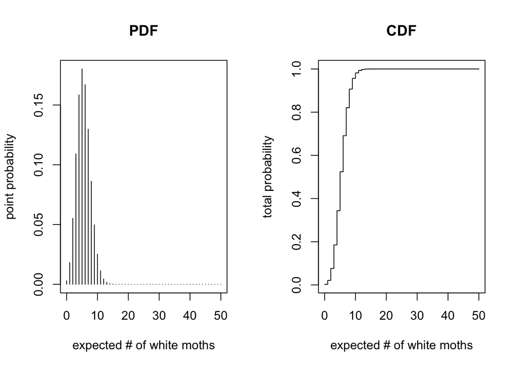

```r
## Option 1: just make a quick plot all in one go
par(mfrow=c(1,2))
x.range = 0:50
plot(x=x.range, y=dbinom(x.range, size=50, prob=0.11), type="h",
     main="PDF",
     xlab="expected # of white moths",
     ylab="point probability")
plot(x=x.range, y=pbinom(x.range, size=50, prob=0.11), type="s",
     main="CDF",
     xlab="expected # of white moths",
     ylab="total probability")
```

```r
## Option 2: step by step

# first specify the expected probability of success
pW = 0.11

# create a vector for the x-axis ranging from 0-50
x.range = 0:50

# PDF and CDF
dbinom.W = dbinom(x = x.range, size = max(x.range), prob=pW)
#dbinom.W
pbinom.W = pbinom(q = x.range, size = max(x.range), prob=pW)
#pbinom.W

# make the plots
# par(mfrow=c(1,2))
# plot(x = x.range, y=dbinom.W, type="h", main="PDF",
#      xlab="expected # of white moths",ylab="point probability")
# plot(x = x.range, y=pbinom.W, type="s", main="CDF",
#      xlab="expected # of white moths",ylab="total probability")
```

6. What kind of data structure would you need to create in order to use the `hist()` function or `ggplot` instead?

```r
# your answer here

## You need to have a vector of the number of successes in each of the individual "observations" (replicates) drawn from a binomial distribution with n=sample size and p=probability of success.
## This is why Bogdan made you go to the trouble to massage your spinner data in recitation! ;-)
```

## Extra credit: write a CDF function

1. Use a loop to compute the the cumulative probability of seeing between **0** and **x** moths in a sample of size **n** by adding up all the discrete probabilities for a discrete variable.
2. Wrap this in a function.
3. Then, call your function to find the total probability of seeing no more than 35/50 white moths, given the null distribution with P(W) = 0.11 or P(W) = 0.87. *Note that for both of the examples here, we considered W to be a success, we just changed p = P(W).*

```r
cdf <- function(x,n,p) {
  result = numeric()
  for (i in 0:x) {  # number of successes
    f = n-i         # number of failures
    q = 1-p         # probability of a failure (p = P(success))
#    result[i] = choose(n,i)*(p^i)*(q^f)  # using binomial formula
    result[i] = dbinom(i,n,p)
  }
  return(sum(result))
}
cdf(35,50,0.11)
```

```
## [1] 0.9970522
```

```r
cdf(35,50,0.87)
```

```
## [1] 0.001285362
```

## Extra credit: Make a histogram of the ideal PDF using ggplot2

*Before you start*, go to this website: [**SticiGui**](https://www.stat.berkeley.edu/~stark/Java/Html/BinHist.htm).

- If you enter (n=50, p=0.11), you will see approximately what the probability distribution for Question 1 should look like. For Question 2, just change p=0.87.

**Follow the example from recitation** to draw plot of the ideal binomial PDF we would expect to get for **x** “successes” in a sample of size **n**, given any probability of “success” **p**.

Let’s also pretend we replicated this on 20 different samples of size 50, so we will be plotting the number of replicates in which we would expect to find 1,2,3,..,49,50 W“successes” out of 50.

Then, follow these steps:

1. Generate a vector of the expected *probability distribution* for the number of “successes” observed out of 50 random trials based on an ideal binomial distribution.
- For P(success), use either P(W) = 0.11 or P(W) = 0.87.
2. Multiply this by the number of replicates to get the **frequency distribution** and round off to the nearest integer.
3. Convert this to a “simple” vector of counts.
4. Finally, make a histogram of these data. This should result in graphs that show the expected number of times that X out of 50 successes were observed in 20 replicate experiments.

```r
# create variables for binomial sampling and initialize them with your choice of p
sample.size = 50
p.success = pW

# probability distribution
ideal.sample = dbinom(0:sample.size, sample.size, p=p.success)

# convert probabilities to frequencies
# (multiply by number of replicate experiments)
replicates = 20
ideal.freq = round(replicates * ideal.sample, digits = 0)
ideal.freq
```

```
##  [1] 0 0 1 2 3 4 3 3 2 1 1 0 0 0 0 0 0 0 0 0 0 0 0 0 0 0 0 0 0 0 0 0 0 0 0 0 0 0
## [39] 0 0 0 0 0 0 0 0 0 0 0 0 0
```

```r
# convert frequencies to count vector of observed proportion of W cells
# e.g. for freq.W = 0 0 1 2 3 4 3 3 2 1 1 0 0 ... we have
# 0 reps with 0 W, 0 reps w/ 1 W, 1 rep w/ 2 W, 2 reps w/ 3W, 3 reps w/ 4 W, etc.
# so we convert this to: counts.W = c(2,3,3,4,4,4,5,5,5,5,6,6,6,7,7,7,8,8,9,10)
ideal.counts = c() # create an empty vector

for (i in 0:sample.size) {
  ideal.counts <- c(ideal.counts,
              rep(i, ideal.freq[i+1]) )
}
ideal.counts
```

```
##  [1]  2  3  3  4  4  4  5  5  5  5  6  6  6  7  7  7  8  8  9 10
```

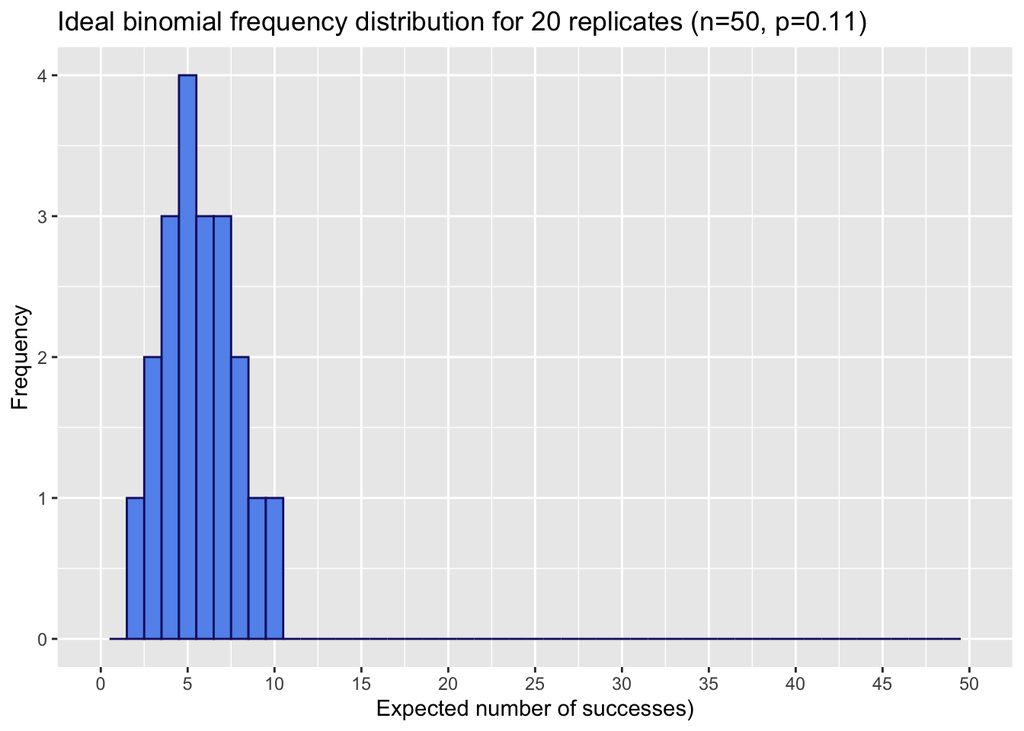

```r
bino_data <- data.frame("successes" = ideal.counts)

# plot all frequencies
ggplot(data = bino_data, mapping = aes(x = successes)) +
  # center columns on integers
  geom_histogram(breaks = seq(from = -0.5, to = sample.size+0.5, by = 1),
                 col = "midnightblue", fill="cornflowerblue") +
  # declutter labels
  scale_x_continuous(name="Expected number of successes)",
                     breaks=seq(0,sample.size,5),
                     limits = c(0,sample.size)) +
  ylab("Frequency") +
  ggtitle(paste0("Ideal binomial frequency distribution for 20 replicates (n=",
  sample.size, ", p=", p.success, ")"))
```

Now answer the following questions:

```r
# here using p=0.11

# What is the most frequent number of W observed out of a sample size of 50?
## for p=0.11, 5
## for p=0.87, 43-44

# How does this gibe with the given probability P(W)?
## 0.11*50  # 5.5
## expect 5 or 6 depending on rounding error, this is consistent with expectation

## 0.87*50 = 43.5, perfect

# What is the total height of all the bars if you sum them all up?
## sum(freq.W) # 20

# What does this number correspond to?
## The number of replicate experiments.

# Where would you expect to the peak of the distribution to be if P(W)  = 0.35?
## round(0.35*50)  # 18
```

[^1]: Disclaimer: I made this up, but based on a true story (see https://en.wikipedia.org/wiki/Peppered_moth_evolution).